# Product Analysis using R

```r
# Libraries

# Wrangling
library(tidyverse)
library(lubridate)
library(scales)

# Summary Statistics
library(outliers)

# Text Analysis
library(stringr)        # text cleaning and regular expressions
library(tidytext)       # provides additional text mining functions
library(widyr)

# Clustering
library(factoextra)
library(cluster)

# Assoc Rules
library("arules")
library("arulesViz")

# Plotting
library(ggplot2)
library(ggrepel)
library(gridExtra)
library(GGally)
library(ggridges)
library(kableExtra)
library(wesanderson)

# Mapping
library(leaflet)
library(sf)
library(RColorBrewer)

# Network Visualization
library(igraph)
library(ggraph)
library(visNetwork)
library(data.table)
```

```r
# Input Path
file_orders <- here::here("03 data/orders.rds")
file_products <- here::here("03 data/product.rds")
file_customers <- here::here("03 data/customers_gender_zip_geocode.rds")
file_co <- here::here("03 data/customers_gender_zip_geocode_orders.rds")
file_zip_ph <- here::here("03 data/zip_ph.rds")

# Read Files
orders.raw <- read_rds(file_orders)
products.raw <- read_rds(file_products)
customers.raw <- read_rds(file_customers)
co.raw <- read_rds(file_co)

# Number Formatting
options(scipen = 999)

# Parameters
# Irrelevant customer_ids
xtest <- c("3273557147747", "3297613348963", "3436247875683", "3210539368547",
           "4412203910", "2236354953315")

# Table Preferences for Kable
tb.ops <- c("striped", "hover", "condensed", "responsive")
```

```r
# Customer Product Data
products.data <-
  products.raw %>%
  inner_join(orders.raw, by = c("order_number" = "order_number")) %>%
  filter(order_year >= 2019) %>%
  rename(customer_id = customer_id.x) %>%
  mutate(has_value = if_else(item_value > 0, "has value", "zero value"),
         has_customer = if_else(is.na(customer_id), "no customer id", "has customer id"))
```

### Product Analysis Overview

This analysis provides an overview of the website’s product assortment focusing on specialty hair products.

Products were categorize according to  
1. **price**  
2. **brand**  
3. **primary need** (e.g., coloring, thinning hair, or damaged hair)

**product type** (e.g., shampoo, conditioner, or treatment) could no be determined for 30% of the orders.  
As a result, it is excluded from the analysis.

### Using text-analysis to group products

The network diagram below shows the most common **product need** and **product type** for each brand, based on the descriptors used in the website. Each brand’s respective websites were also consulted to confirm its positioning.

[interactive chart not shown]

### Pricing distribution

The ridge plots below show how certain product groups are typically priced higher, or lower than the average. It is also evident some product groups, such as *colored hair* and *L’oreal* occupy a wide range of price points.

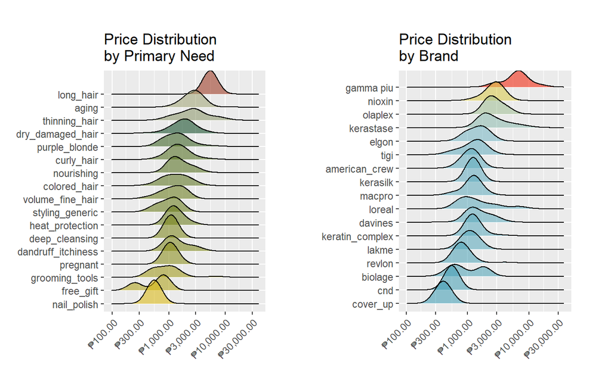

### Product positioning

Brands can also be plotted against sales volume and average price to determine their relative market position. In the chart below, size and opacity indicate the brand’s share of total company revenue.

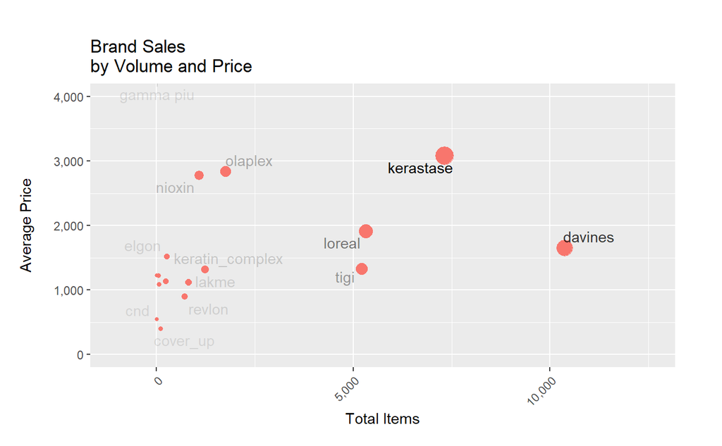

Plotting the median line shows each each brand’s impact on the portfolio. Davines has the highest volume, and sells at the average price. Kerastase, Nioxin and Olaplex are high-price products, but Keratase also sells high-volumes. Meanwhile, L’oreal and Tigi sell similar volumes, but Tigi’s selling price is below average.

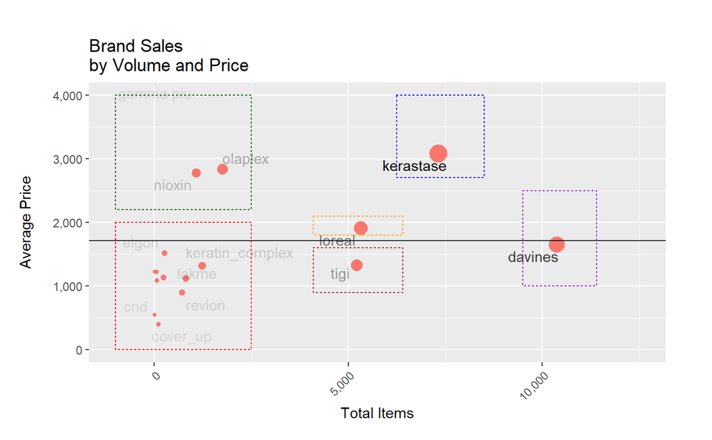

Plotting the brands against product needs shows how some top brands, such as Nioxin and Olaplex, are highly focused on specific needs, while Kerastase, davines, L’oreal, and TIGI cater to a wider set of needs.

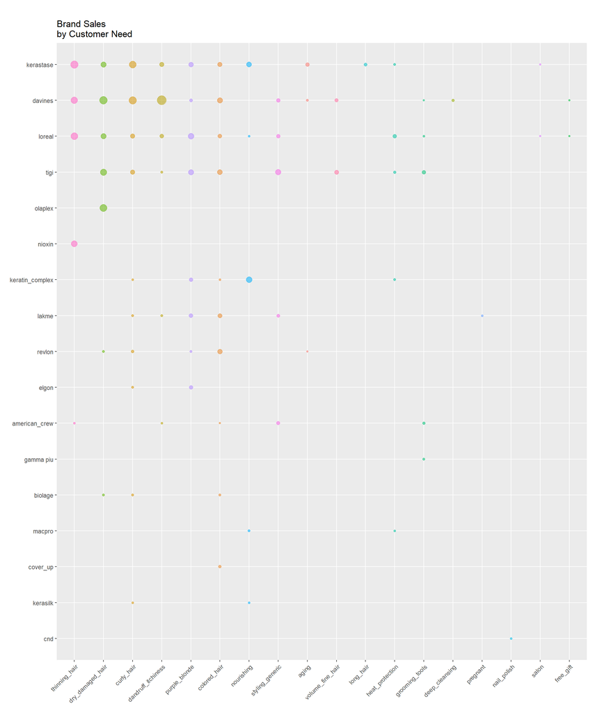